# Testint the Normality Independence of the Stock Market Returns

The study of the log-returns for the price of the stocks is one of the most popular metric in mathematical finance. Usually is assumed that the price dynamics of the stocks are driven by geometric Brownian motion and thus, the log-return of the prices are **independent** and **normally distributed**.

# Getting Data

We firstly load the database of the stock exchange subject to study, and from that we exctract the adjusted final price of each day. A simple plot will let us take a look at what we have.

```r
sp500 <- new.env()
getSymbols("^GSPC", env = sp500, src = "yahoo", from = as.Date("1950-01-01"), to = as.Date("2017-12-31"))
```

[output not shown]

```
[1] "GSPC"
```

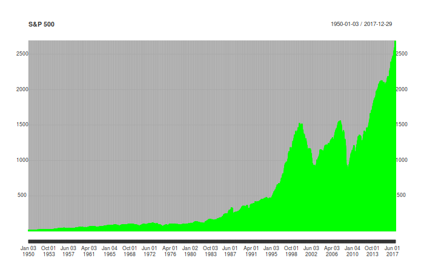

```r
GSPC <- sp500$GSPC
plot(GSPC$GSPC.Adjusted, type ="h", main="S&P 500", ylim = c(0, max(GSPC$GSPC.Adjusted)))
```

For this work, we would like to study the logreturn of the price; defined as the difference of the logarithm of the price. Is interesting to notice some historically relevant outliers.

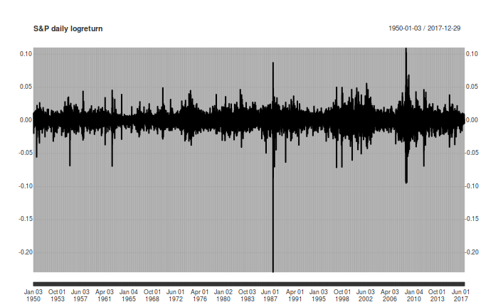

```r
lr <- diff(log(GSPC$GSPC.Adjusted))
plot(lr, main = "S&P daily logreturn", ylab="logreturn")
```

# Normality

A histogram showing the frequency of these logreturns should hint us about the normality of its distribution.

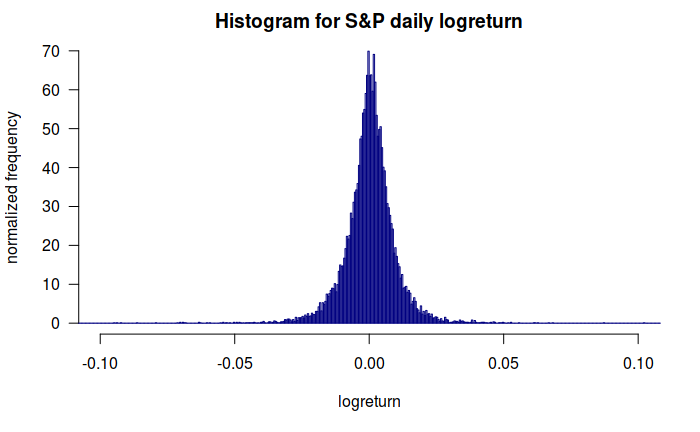

```r
hlr <- hist(lr, main = "Histogram for S&P daily logreturn", xlab="logreturn", ylab="normalized frequency", border="navy blue", xlim=c(-0.1,0.1), las=1, breaks=500, prob=TRUE)
```

Is this a *normal* distribution? There are several different means to check thte normality of a distribution. One widely used way is to perform an statistical test, such as the *Anderson-Darling* normality test:

```r
ad.test(lr)
```

[output not shown]

```
    Anderson-Darling normality test

data:  lr
A = 16851, p-value < 2.2e-16
```

Knowing that the null hypothesis of this test is the normality of the distribution, such small p-value leads us to reject the assumption of normality of our data.

# Independence

When a newcommer arrives into the financial world, one common chimera is to find patters in the time series of price in order to predict future prices. No one can be blamed for that dream, for such ability would harvest a lot of money.

One reasonable question to ask would be whether or not some patterns do exist in the stock exchange price time series. We start taking a look at the autocorrelation function.

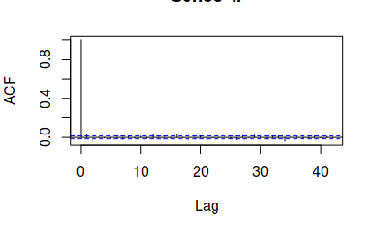

```r
corr <- acf(lr, na.action = na.pass)
```

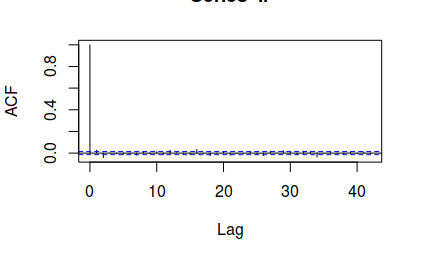

```r
plot(corr)
```

Is not easy to extract conclusions from this plot. There are some values different of 0; but these values are small enough to not consider its correaltions strong enough.

One simple way to address this enigma would be testing the time independence of the values of the price time series.

```r
mean <- mean(lr, na.rm = TRUE)
lr[is.na(lr)] <- mean
adf.test(lr)
```

```
p-value smaller than printed p-value
```

```
    Augmented Dickey-Fuller Test

data:  lr
Dickey-Fuller = -26.559, Lag order = 25, p-value = 0.01
alternative hypothesis: stationary
```